# Pruebas de Hipótesis

Edimer David Jaramillo

31 de mayo de 2018

# Introducción

- **Punto de partida:** situaciones cotidianas que afectan la realidad del hombre.
- Tomar acciones frente a dichas situaciones requiere comprensión del sistema que las origina.
- **Etapa de “idealización”:** modelación
  - La modelación tiene como objetivo identificar los elementos que son importantes y determinar sus relaciones.
- Si el modelo es correcto, se constituye como una herramienta útil para planificar acciones.

**Relación entre la construcción de modelos y la inferencia estadística:**

- Un modelo deber ser validado, es decir, mostrar que las estimaciones que se deducen del mismo, son aceptables.
- Un modelo se considera correcto para determinada situación, cuano no existen **diferencias significativas** entre lo observado y lo esperado.
- ¿Qué es diferencia significativa?
  - Asignación de probabilidades al evento
  - La medida de probabilidad permitirá tomar la decisión basado en la evidencia observada
- **Hipótesis científica:** modelo no validado
  - Si las consecuencias de la hipótesis científica se puede establecer como propiedades estadísticas de una variable aleatoria, entonces será posible implementar herramientas de inferencia estadística que permitan la validación del modelo.
  - Hipótesis científica en términos estadísticos como *Hipótesis Estadística*
    - Analizar datos muestrales
    - Cálculo de estadísticos muestrales
    - Distribución del estadístico muestral
    - La distribución del estadístico depende de la hipótesis planteada
    - Se rechaza o no la hipótesis estadística y, en consecuencia, la hipótesis científica

# Tipos de hipótesis

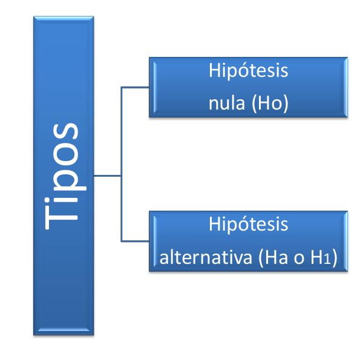

# Tipos de pruebas

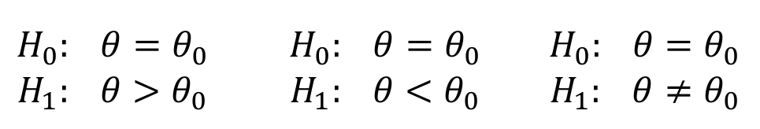

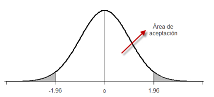

# Pruebas de hipótesis usuales

- Para una muestra:
  - $\mu$
  - $p$
  - $\sigma^2$
- Para dos muestras:
  - $\mu_1 - \mu_2$
  - $\mu_1 - \mu_2\ (pareadas)$
  - $p_1-p_2$
  - $\sigma^2_1/\sigma^2_2$

# Proceso de prueba de hipótesis

- Definir la hipótesis nula y la alternativa
- Tomar la muestra (muestreo)
- Calcular el estadístico (evidencias)
- Determinar el nivel $\alpha$
- Calcular el valor P
- Concluir (toma de decisiones)

# Tipos de errores en pruebas de hipótesis

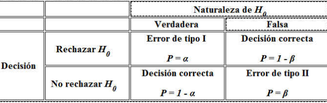

- $\alpha$: máxima probabilidad de cometer el error tipo I
- **Potencia de la prueba ($1- \beta$):** probabilidad de rechazar una hipótesis nula que es falsa.

# Valor P: concepto

- Se puede definir como la probabilidad exacta de cometer el error tipo I.
- Probabilidad de obtener un estadístico de prueba (evidencias) igual al que se obtuvo o más extremo.
- Es la probabilidad calculada, suponiendo que la hipótesis nula es verdadera, de obtener un estadístico de prueba tan discrepante a $H_0$ como el valor que en realidad se obtuvo.
- En la medida que el valor P se hace más pequeño, más contradictorios son los datos con $H_0$

**¿Dónde se encuenta el valor P?**

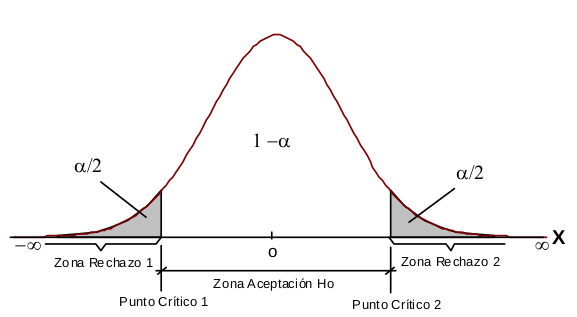

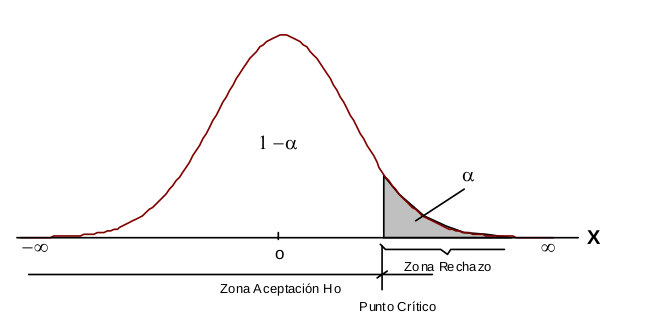

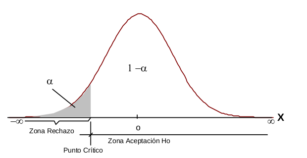

# Conclusión en una prueba de hipótesis

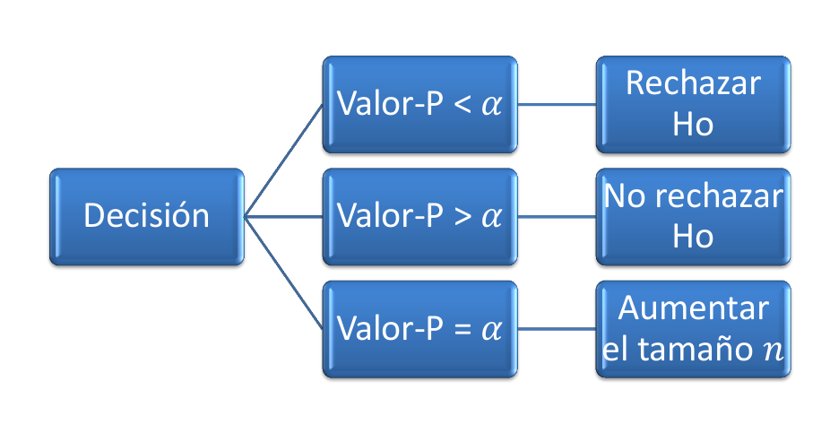

# Formas de contrastar una hipótesis

- Intervalos de confianza
- Región de rechazo
- Valor P

# Hipótesis para una muestra

## Hipótesis para $\mu$

1. Comprobar que la variable aleatoria se distribuye de forma normal.
2. Definir la hipóteis nula y alternativa:
   $$H_0: nula \\
   H_1: alternativa$$
3. Calcular el estadístico
   $$t = \frac{\bar{X}- \mu_0}{s/\sqrt{n}}$$
4. Definir el error tipo I $\alpha$
5. Calcular el valor P en una distribución $t-student$ con $n-1$ grados de libertad
6. Comparar el valor P con $\alpha$ y concluir

## Hipótesis para $p$

1. Definir la hipótesis nula y alternativa
   $$H_0: nula \\
   H_1: alternativa$$
2. Calcular el estadístico
   $$Z_0 = \frac{\hat{p}-p_0}{\sqrt{\frac{p_0(1-p_0)}{n}}}$$
3. Definir el error tipo I $\alpha$
4. Calcular el valor P en una distribución normal estándar
5. Comparar el valor P con $\alpha$ y concluir

# Hipótesis para dos muestras

## Hipótesis para $\mu_1-\mu_2$ con varianzas desconocidas e iguales

**Previamente:**

- Comprobar normalidad

**Luego:**

1. Definir la hipótesis nula y alternativa
   $$H_0: nula \\
   H_1: alternativa$$
2. Calcular el estadístico

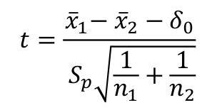

Donde:

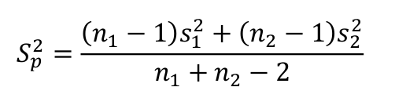

3. Definir el error tipo I $\alpha$
4. Calcular el valor P
5. Comparar el valor P con $\alpha$ y concluir

## Hipótesis para $\mu_1-\mu_2$ con varianzas desconocidas y diferentes

**Previamente:**

- Comprobar normalidad
- Comprobar homogeneidad de varianzas

**Luego:**

1. Definir la hipótesis nula y alternativa
2. Calcular el estadístico

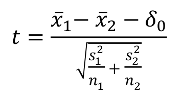

Donde $t \sim t_v$ con grados de libertad $v$:

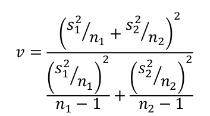

3. Definir el error tipo I $\alpha$
4. Calcular el valor P
5. Comparar el valor P con $\alpha$ y concluir

**Previamente:**

- Comprobar normalidad
- Comprobar homogeneidad de varianzas

**Luego:**

1. Definir la hipótesis nula y alternativa
2. Calcular el estadístico

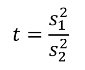

3. Definir el error tipo I $\alpha$
4. Calcular el valor P
5. Comparar el valor P con $\alpha$ y concluir